# Project_4_Premani

## Background and Context

You are a Data Scientist for a tourism company named "Visit with us". The Policy Maker of the company wants to enable and establish a viable business model to expand the customer base. A viable business model is a central concept that helps you to understand the existing ways of doing the business and how to change the ways for the benefit of the tourism sector. One of the ways to expand the customer base is to introduce a new offering of packages.

Currently, there are 5 types of packages the company is offering - Basic, Standard, Deluxe, Super Deluxe, King. Looking at the data of the last year, we observed that 18% of the customers purchased the packages. However, the marketing cost was quite high because customers were contacted at random without looking at the available information. The company is now planning to launch a new product i.e. Wellness Tourism Package. Wellness Tourism is defined as Travel that allows the traveler to maintain, enhance or kick-start a healthy lifestyle, and support or increase one's sense of well-being.

However, this time company wants to harness the available data of existing and potential customers to make the marketing expenditure more efficient. You as a Data Scientist at "Visit with us" travel company have to analyze the customers' data and information to provide recommendations to the Policy Maker and Marketing Team and also build a model to predict the potential customer who is going to purchase the newly introduced travel package.

## Objective

To predict which customer is more likely to purchase the newly introduced travel package.

## Data Dictionary

Customer details:

- CustomerID: Unique customer ID
- ProdTaken: Whether the customer has purchased a package or not (0: No, 1: Yes)
- Age: Age of customer
- TypeofContact: How customer was contacted (Company Invited or Self Inquiry)
- CityTier: City tier depends on the development of a city, population, facilities, and living standards. The categories are ordered i.e. Tier 1 > Tier 2 > Tier 3
- Occupation: Occupation of customer
- Gender: Gender of customer
- NumberOfPersonVisiting: Total number of persons planning to take the trip with the customer
- PreferredPropertyStar: Preferred hotel property rating by customer
- MaritalStatus: Marital status of customer
- NumberOfTrips: Average number of trips in a year by customer
- Passport: The customer has a passport or not (0: No, 1: Yes)
- OwnCar: Whether the customers own a car or not (0: No, 1: Yes)
- NumberOfChildrenVisiting: Total number of children with age less than 5 planning to take the trip with the customer
- Designation: Designation of the customer in the current organization
- MonthlyIncome: Gross monthly income of the customer

Customer interaction data:

- PitchSatisfactionScore: Sales pitch satisfaction score
- ProductPitched: Product pitched by the salesperson
- NumberOfFollowups: Total number of follow-ups has been done by the salesperson after the sales pitch
- DurationOfPitch: Duration of the pitch by a salesperson to the customer

## Preliminary Thoughts

The company has viable data that can be used to train various ML Models to predict how new packages should be marketed. However, we should keep in mind that the ML models will help us profile customers, but not tell us which customers would like to sign up for the Wellness Tourism Package specifically. This might create a bias that will not be captured by our model(s) because we do not know which customers would like the benefits of the Wellness Tourism Package. A way to capture that would be to assign weights to the five types of packages by considering which packages more closely match the benefits of the Wellness Tourism Package, and then train the model accordingly.

## Loading and Preparing Data

```python
# import necessary libraries and packages
import warnings
warnings.filterwarnings("ignore")

import numpy as np
import pandas as pd
import seaborn as sns
import matplotlib.pyplot as plt

from sklearn import tree
from sklearn.tree import DecisionTreeClassifier

from sklearn.ensemble import BaggingClassifier,RandomForestClassifier, \
    GradientBoostingClassifier, AdaBoostClassifier, StackingClassifier
from xgboost import XGBClassifier
from sklearn import metrics

from sklearn.model_selection import GridSearchCV, train_test_split
```

```python
# import data into pandas dataframe. Tourism.xlsx second sheet was converted into .csv as 'Tourism.csv'
df = pd.read_csv('Tourism.csv')
df.shape
```

```
(4888, 20)
```

```python
np.random.seed(1)
df.sample(n=10)
```

|  | CustomerID | ProdTaken | Age | TypeofContact | CityTier | DurationOfPitch | Occupation | Gender | NumberOfPersonVisiting | NumberOfFollowups | ProductPitched | PreferredPropertyStar | MaritalStatus | NumberOfTrips | Passport | PitchSatisfactionScore | OwnCar | NumberOfChildrenVisiting | Designation | MonthlyIncome |
| --- | --- | --- | --- | --- | --- | --- | --- | --- | --- | --- | --- | --- | --- | --- | --- | --- | --- | --- | --- | --- |
| 3015 | 203015 | 0 | 27.0 | Company Invited | 1 | 7.0 | Salaried | Female | 4 | 6.0 | Basic | 3.0 | Married | 5.0 | 0 | 4 | 1 | 3.0 | Executive | 23042.0 |
| 1242 | 201242 | 0 | 40.0 | Self Enquiry | 3 | 13.0 | Small Business | Male | 2 | 3.0 | King | 4.0 | Single | 2.0 | 0 | 4 | 1 | NaN | VP | 34833.0 |
| 3073 | 203073 | 0 | 29.0 | Self Enquiry | 2 | 15.0 | Small Business | Male | 4 | 5.0 | Basic | 3.0 | Married | 3.0 | 0 | 2 | 0 | 2.0 | Executive | 23614.0 |
| 804 | 200804 | 0 | 48.0 | Company Invited | 1 | 6.0 | Small Business | Male | 2 | 1.0 | Super Deluxe | 3.0 | Single | 3.0 | 0 | 2 | 0 | 0.0 | AVP | 31885.0 |
| 3339 | 203339 | 0 | 32.0 | Self Enquiry | 1 | 18.0 | Small Business | Male | 4 | 4.0 | Deluxe | 5.0 | Divorced | 3.0 | 1 | 2 | 0 | 3.0 | Manager | 25511.0 |
| 3080 | 203080 | 1 | 36.0 | Company Invited | 1 | 32.0 | Salaried | Female | 4 | 4.0 | Basic | 4.0 | Married | 3.0 | 1 | 3 | 0 | 1.0 | Executive | 20700.0 |
| 2851 | 202851 | 0 | 46.0 | Self Enquiry | 1 | 17.0 | Salaried | Male | 4 | 4.0 | Basic | 3.0 | Divorced | 5.0 | 0 | 5 | 1 | 1.0 | Executive | 21332.0 |
| 2883 | 202883 | 1 | 32.0 | Company Invited | 1 | 27.0 | Salaried | Male | 4 | 4.0 | Standard | 3.0 | Divorced | 5.0 | 0 | 3 | 1 | 1.0 | Senior Manager | 28502.0 |
| 1676 | 201676 | 0 | 22.0 | Self Enquiry | 1 | 11.0 | Salaried | Male | 2 | 1.0 | Basic | 4.0 | Married | 2.0 | 1 | 4 | 1 | 0.0 | Executive | 17328.0 |
| 1140 | 201140 | 0 | 44.0 | Self Enquiry | 1 | 13.0 | Small Business | Female | 2 | 3.0 | King | 3.0 | Married | 1.0 | 1 | 4 | 1 | 1.0 | VP | 34049.0 |

We can remove the CustomerID column.

```python
df.drop(columns='CustomerID', inplace=True)
```

```python
df.info()
```

```
<class 'pandas.core.frame.DataFrame'>
RangeIndex: 4888 entries, 0 to 4887
Data columns (total 19 columns):
 #   Column                    Non-Null Count  Dtype
---  ------                    --------------  -----
 0   ProdTaken                 4888 non-null   int64
 1   Age                       4662 non-null   float64
 2   TypeofContact             4863 non-null   object
 3   CityTier                  4888 non-null   int64
 4   DurationOfPitch           4637 non-null   float64
 5   Occupation                4888 non-null   object
 6   Gender                    4888 non-null   object
 7   NumberOfPersonVisiting    4888 non-null   int64
 8   NumberOfFollowups         4843 non-null   float64
 9   ProductPitched            4888 non-null   object
 10  PreferredPropertyStar     4862 non-null   float64
 11  MaritalStatus             4888 non-null   object
 12  NumberOfTrips             4748 non-null   float64
 13  Passport                  4888 non-null   int64
 14  PitchSatisfactionScore    4888 non-null   int64
 15  OwnCar                    4888 non-null   int64
 16  NumberOfChildrenVisiting  4822 non-null   float64
 17  Designation               4888 non-null   object
 18  MonthlyIncome             4655 non-null   float64
dtypes: float64(7), int64(6), object(6)
memory usage: 725.7+ KB
```

We have 6 object (string) columns, and the rest are float/int.

```python
df.describe().T
```

|  | count | mean | std | min | 25% | 50% | 75% | max |
| --- | --- | --- | --- | --- | --- | --- | --- | --- |
| ProdTaken | 4888.0 | 0.188216 | 0.390925 | 0.0 | 0.0 | 0.0 | 0.0 | 1.0 |
| Age | 4662.0 | 37.622265 | 9.316387 | 18.0 | 31.0 | 36.0 | 44.0 | 61.0 |
| CityTier | 4888.0 | 1.654255 | 0.916583 | 1.0 | 1.0 | 1.0 | 3.0 | 3.0 |
| DurationOfPitch | 4637.0 | 15.490835 | 8.519643 | 5.0 | 9.0 | 13.0 | 20.0 | 127.0 |
| NumberOfPersonVisiting | 4888.0 | 2.905074 | 0.724891 | 1.0 | 2.0 | 3.0 | 3.0 | 5.0 |
| NumberOfFollowups | 4843.0 | 3.708445 | 1.002509 | 1.0 | 3.0 | 4.0 | 4.0 | 6.0 |
| PreferredPropertyStar | 4862.0 | 3.581037 | 0.798009 | 3.0 | 3.0 | 3.0 | 4.0 | 5.0 |
| NumberOfTrips | 4748.0 | 3.236521 | 1.849019 | 1.0 | 2.0 | 3.0 | 4.0 | 22.0 |
| Passport | 4888.0 | 0.290917 | 0.454232 | 0.0 | 0.0 | 0.0 | 1.0 | 1.0 |
| PitchSatisfactionScore | 4888.0 | 3.078151 | 1.365792 | 1.0 | 2.0 | 3.0 | 4.0 | 5.0 |
| OwnCar | 4888.0 | 0.620295 | 0.485363 | 0.0 | 0.0 | 1.0 | 1.0 | 1.0 |
| NumberOfChildrenVisiting | 4822.0 | 1.187267 | 0.857861 | 0.0 | 1.0 | 1.0 | 2.0 | 3.0 |
| MonthlyIncome | 4655.0 | 23619.853491 | 5380.698361 | 1000.0 | 20346.0 | 22347.0 | 25571.0 | 98678.0 |

Summary:

```python
cols = ['ProdTaken', 'CityTier', 'Passport', 'OwnCar', 'Gender', 'MaritalStatus', \
        'Designation', 'TypeofContact','Occupation']
for col in cols:
    print(df[col].value_counts())
    print('*' * 40)
```

```
0    3968
1     920
Name: ProdTaken, dtype: int64
1    3190
3    1500
2     198
Name: CityTier, dtype: int64
0    3466
1    1422
Name: Passport, dtype: int64
1    3032
0    1856
Name: OwnCar, dtype: int64
Male       2916
Female     1817
Fe Male     155
Name: Gender, dtype: int64
Married      2340
Divorced      950
Single        916
Unmarried     682
Name: MaritalStatus, dtype: int64
Executive         1842
Manager           1732
Senior Manager     742
AVP                342
VP                 230
Name: Designation, dtype: int64
Self Enquiry       3444
Company Invited    1419
Name: TypeofContact, dtype: int64
Salaried          2368
Small Business    2084
Large Business     434
Free Lancer          2
Name: Occupation, dtype: int64
```

Note:

- Gender has two Female categories - we should rename "Fe Male" to "Female".
- MaritalStatus has two duplicate categories: Unmarried and Single. We will merge these two.

```python
df.loc[df['Gender']=='Fe Male','Gender'] = 'Female'
df['Gender'].value_counts()
```

```
Male      2916
Female    1972
Name: Gender, dtype: int64
```

```python
df.loc[df['MaritalStatus']=='Unmarried','MaritalStatus'] = 'Single'
df['MaritalStatus'].value_counts()
```

```
Married     2340
Single      1598
Divorced     950
Name: MaritalStatus, dtype: int64
```

## Missing Value Treatment

```python
def display_missing(df):
    list1 = ['ProdTaken', 'Passport', 'OwnCar']
    print('Number columns:')
    cond1 = (df.dtypes == 'float64') + (df.dtypes == 'int64') # selecting float columns
    cond2 = df.isnull().sum() > 0  # selecting columns with NaN values
    cond_ = np.logical_and(cond1.values, cond2.values)

    for col_name in df.columns[cond1.values]:
        if col_name not in list1:
            a = df[col_name].apply(lambda x: x == 0).sum()
            b = df[col_name].isnull().sum()
            if (a != 0) or (b != 0):
                print(f"{col_name} has {b} NaN values and {a} zero values ")

    print('*' * 40)
    print('String columns:')
    cond1 = (df.dtypes == 'object')
    for col_name in df.columns[cond1.values]:
        a = df[col_name].eq('').sum()
        if (a != 0):
            print(f"{col_name} has {a} empty values.")

display_missing(df)
```

```
Number columns:
Age has 226 NaN values and 0 zero values
DurationOfPitch has 251 NaN values and 0 zero values
NumberOfFollowups has 45 NaN values and 0 zero values
PreferredPropertyStar has 26 NaN values and 0 zero values
NumberOfTrips has 140 NaN values and 0 zero values
NumberOfChildrenVisiting has 66 NaN values and 1082 zero values
MonthlyIncome has 233 NaN values and 0 zero values
String columns:
```

Most of the above columns have NaN values, and NumberOfChildrenVisiting has some 0 values - that is alright since people can have 0 children. We must deal with the rest of the columns' NaN values. No string columns have empty values, which is good. Let's see if there exist any patterns in the NaN values by looking at columns that have the most number of NaN values.

```python
np.random.seed(1)
df.loc[df['Age'].isnull(),:].sample(n=10)
```

|  | ProdTaken | Age | TypeofContact | CityTier | DurationOfPitch | Occupation | Gender | NumberOfPersonVisiting | NumberOfFollowups | ProductPitched | PreferredPropertyStar | MaritalStatus | NumberOfTrips | Passport | PitchSatisfactionScore | OwnCar | NumberOfChildrenVisiting | Designation | MonthlyIncome |
| --- | --- | --- | --- | --- | --- | --- | --- | --- | --- | --- | --- | --- | --- | --- | --- | --- | --- | --- | --- |
| 481 | 0 | NaN | Self Enquiry | 1 | 6.0 | Salaried | Male | 2 | 4.0 | Basic | 3.0 | Divorced | 2.0 | 1 | 2 | 0 | 0.0 | Executive | 18622.0 |
| 1793 | 1 | NaN | Self Enquiry | 1 | 8.0 | Small Business | Male | 2 | 5.0 | Basic | 3.0 | Married | 6.0 | 1 | 3 | 1 | 1.0 | Executive | 18464.0 |
| 1032 | 1 | NaN | Company Invited | 1 | 8.0 | Salaried | Female | 2 | 4.0 | Basic | 5.0 | Single | 3.0 | 1 | 3 | 0 | 0.0 | Executive | 18646.0 |
| 740 | 0 | NaN | Self Enquiry | 1 | 16.0 | Salaried | Male | 2 | 3.0 | Basic | 3.0 | Married | 2.0 | 0 | 5 | 1 | 0.0 | Executive | NaN |
| 2136 | 1 | NaN | Self Enquiry | 1 | 9.0 | Salaried | Female | 2 | 3.0 | Deluxe | 3.0 | Married | 1.0 | 1 | 5 | 1 | 1.0 | Manager | NaN |
| 2035 | 0 | NaN | Self Enquiry | 1 | 16.0 | Small Business | Male | 3 | 1.0 | Basic | 3.0 | Single | 2.0 | 0 | 1 | 0 | 1.0 | Executive | 18505.0 |
| 449 | 0 | NaN | Company Invited | 1 | 14.0 | Salaried | Female | 2 | 3.0 | Basic | 3.0 | Divorced | 2.0 | 0 | 2 | 0 | 0.0 | Executive | NaN |
| 1286 | 0 | NaN | Self Enquiry | 1 | 8.0 | Salaried | Female | 2 | 3.0 | Basic | 5.0 | Married | 5.0 | 0 | 4 | 1 | 1.0 | Executive | 18377.0 |
| 1157 | 0 | NaN | Company Invited | 1 | 14.0 | Salaried | Female | 2 | 3.0 | Deluxe | 3.0 | Married | 2.0 | 0 | 5 | 1 | 1.0 | Manager | NaN |
| 1020 | 0 | NaN | Self Enquiry | 1 | 6.0 | Large Business | Male | 3 | 3.0 | Basic | 3.0 | Divorced | 1.0 | 0 | 3 | 1 | 0.0 | Executive | 18420.0 |

```python
np.random.seed(1)
df.loc[df['MonthlyIncome'].isnull(),:].sample(n=10)
```

|  | ProdTaken | Age | TypeofContact | CityTier | DurationOfPitch | Occupation | Gender | NumberOfPersonVisiting | NumberOfFollowups | ProductPitched | PreferredPropertyStar | MaritalStatus | NumberOfTrips | Passport | PitchSatisfactionScore | OwnCar | NumberOfChildrenVisiting | Designation | MonthlyIncome |
| --- | --- | --- | --- | --- | --- | --- | --- | --- | --- | --- | --- | --- | --- | --- | --- | --- | --- | --- | --- |
| 2336 | 0 | 40.0 | Company Invited | 3 | NaN | Small Business | Male | 3 | 3.0 | Deluxe | 4.0 | Married | 6.0 | 0 | 4 | 1 | 1.0 | Manager | NaN |
| 960 | 0 | NaN | Company Invited | 3 | 6.0 | Small Business | Female | 3 | 3.0 | Deluxe | 5.0 | Married | 1.0 | 0 | 3 | 0 | 1.0 | Manager | NaN |
| 1859 | 0 | NaN | Self Enquiry | 1 | 16.0 | Salaried | Male | 2 | 3.0 | Deluxe | 4.0 | Single | 3.0 | 1 | 5 | 0 | 1.0 | Manager | NaN |
| 767 | 0 | NaN | Self Enquiry | 1 | 9.0 | Salaried | Female | 2 | 3.0 | Deluxe | 4.0 | Single | 4.0 | 0 | 4 | 1 | 0.0 | Manager | NaN |
| 1163 | 0 | NaN | Self Enquiry | 1 | 16.0 | Small Business | Female | 3 | 3.0 | Basic | 4.0 | Married | 2.0 | 0 | 1 | 1 | 0.0 | Executive | NaN |
| 961 | 0 | 35.0 | Company Invited | 1 | NaN | Salaried | Male | 2 | 3.0 | Deluxe | 3.0 | Single | 2.0 | 1 | 1 | 1 | 1.0 | Manager | NaN |
| 893 | 0 | NaN | Self Enquiry | 1 | 6.0 | Salaried | Female | 3 | 3.0 | Basic | 3.0 | Married | 2.0 | 0 | 2 | 0 | 2.0 | Executive | NaN |
| 1230 | 0 | NaN | Self Enquiry | 1 | 35.0 | Small Business | Male | 3 | 3.0 | Basic | 5.0 | Married | 2.0 | 0 | 4 | 1 | 1.0 | Executive | NaN |
| 2410 | 1 | NaN | Self Enquiry | 1 | 30.0 | Small Business | Male | 2 | 3.0 | Basic | 4.0 | Married | 2.0 | 1 | 1 | 0 | 0.0 | Executive | NaN |
| 676 | 0 | NaN | Self Enquiry | 1 | 27.0 | Salaried | Female | 2 | 3.0 | Deluxe | 3.0 | Divorced | 2.0 | 1 | 3 | 0 | 1.0 | Manager | NaN |

```python
np.random.seed(1)
df.loc[df['DurationOfPitch'].isnull(),:].sample(n=10)
```

|  | ProdTaken | Age | TypeofContact | CityTier | DurationOfPitch | Occupation | Gender | NumberOfPersonVisiting | NumberOfFollowups | ProductPitched | PreferredPropertyStar | MaritalStatus | NumberOfTrips | Passport | PitchSatisfactionScore | OwnCar | NumberOfChildrenVisiting | Designation | MonthlyIncome |
| --- | --- | --- | --- | --- | --- | --- | --- | --- | --- | --- | --- | --- | --- | --- | --- | --- | --- | --- | --- |
| 724 | 0 | 24.0 | NaN | 1 | NaN | Small Business | Female | 2 | 4.0 | Deluxe | 3.0 | Married | 2.0 | 0 | 3 | 1 | 1.0 | Manager | NaN |
| 4825 | 1 | 26.0 | Self Enquiry | 1 | NaN | Salaried | Male | 3 | 4.0 | Basic | 5.0 | Married | 6.0 | 0 | 5 | 1 | 1.0 | Executive | 19796.0 |
| 2409 | 1 | 32.0 | Self Enquiry | 1 | NaN | Small Business | Male | 2 | 3.0 | Deluxe | 4.0 | Married | 5.0 | 0 | 4 | 1 | 1.0 | Manager | 19883.0 |
| 1779 | 0 | 31.0 | Self Enquiry | 1 | NaN | Large Business | Male | 2 | 3.0 | Basic | 3.0 | Married | 1.0 | 1 | 4 | 1 | 0.0 | Executive | 19821.0 |
| 949 | 0 | 39.0 | Self Enquiry | 1 | NaN | Salaried | Male | 2 | 3.0 | Deluxe | 3.0 | Single | 1.0 | 0 | 3 | 0 | 0.0 | Manager | 19534.0 |
| 2342 | 0 | 33.0 | Company Invited | 3 | NaN | Small Business | Female | 2 | 3.0 | Deluxe | 3.0 | Married | 2.0 | 0 | 3 | 0 | 1.0 | Manager | 19539.0 |
| 630 | 0 | 22.0 | Self Enquiry | 1 | NaN | Salaried | Male | 2 | 4.0 | Deluxe | 3.0 | Divorced | 7.0 | 0 | 2 | 1 | 0.0 | Manager | 19775.0 |
| 2431 | 1 | 35.0 | Company Invited | 1 | NaN | Small Business | Male | 3 | 3.0 | Basic | 4.0 | Married | 2.0 | 1 | 3 | 1 | 0.0 | Executive | NaN |
| 1931 | 0 | 35.0 | Self Enquiry | 3 | NaN | Small Business | Female | 3 | 3.0 | Deluxe | 3.0 | Single | 2.0 | 0 | 4 | 1 | 0.0 | Manager | 19859.0 |
| 103 | 0 | 34.0 | Self Enquiry | 1 | NaN | Salaried | Female | 2 | 3.0 | Deluxe | 3.0 | Single | 2.0 | 0 | 3 | 1 | 0.0 | Manager | 19809.0 |

```python
np.random.seed(1)
df.loc[df['NumberOfTrips'].isnull(),:].sample(n=10)
```

|  | ProdTaken | Age | TypeofContact | CityTier | DurationOfPitch | Occupation | Gender | NumberOfPersonVisiting | NumberOfFollowups | ProductPitched | PreferredPropertyStar | MaritalStatus | NumberOfTrips | Passport | PitchSatisfactionScore | OwnCar | NumberOfChildrenVisiting | Designation | MonthlyIncome |
| --- | --- | --- | --- | --- | --- | --- | --- | --- | --- | --- | --- | --- | --- | --- | --- | --- | --- | --- | --- |
| 3570 | 0 | 51.0 | Self Enquiry | 3 | 6.0 | Small Business | Male | 3 | 4.0 | King | 3.0 | Married | NaN | 1 | 5 | 0 | 2.0 | VP | 38009.0 |
| 3380 | 0 | 46.0 | Company Invited | 1 | 32.0 | Small Business | Female | 3 | 4.0 | King | 4.0 | Single | NaN | 0 | 4 | 1 | 2.0 | VP | 36739.0 |
| 3185 | 0 | 43.0 | Self Enquiry | 3 | 12.0 | Small Business | Male | 3 | 4.0 | King | 3.0 | Divorced | NaN | 0 | 4 | 0 | 2.0 | VP | 36981.0 |
| 4391 | 0 | 51.0 | Company Invited | 2 | 10.0 | Small Business | Male | 4 | 4.0 | King | 4.0 | Married | NaN | 0 | 1 | 1 | 3.0 | VP | 36878.0 |
| 2556 | 0 | 55.0 | Company Invited | 2 | 33.0 | Salaried | Female | 2 | 3.0 | Super Deluxe | 3.0 | Single | NaN | 1 | 3 | 1 | 1.0 | AVP | 36006.0 |
| 4026 | 0 | 55.0 | Company Invited | 2 | 33.0 | Salaried | Female | 2 | 2.0 | Super Deluxe | 3.0 | Single | NaN | 1 | 3 | 1 | 1.0 | AVP | 36006.0 |
| 2921 | 0 | 51.0 | Company Invited | 2 | 10.0 | Small Business | Male | 3 | 4.0 | King | 4.0 | Divorced | NaN | 0 | 2 | 1 | 1.0 | VP | 36878.0 |
| 2734 | 0 | 50.0 | Company Invited | 1 | 17.0 | Salaried | Female | 3 | 4.0 | King | 5.0 | Single | NaN | 1 | 3 | 0 | 1.0 | VP | 37343.0 |
| 3381 | 0 | 40.0 | Self Enquiry | 1 | 20.0 | Small Business | Female | 4 | 5.0 | Super Deluxe | 4.0 | Married | NaN | 1 | 3 | 1 | 3.0 | AVP | 35801.0 |
| 3795 | 0 | 49.0 | Company Invited | 1 | 29.0 | Small Business | Female | 3 | 4.0 | Super Deluxe | 3.0 | Married | NaN | 0 | 5 | 0 | 1.0 | AVP | 35852.0 |

The NaN values seem to be independent of each other, which means that maybe we don't have to delete any rows, and can start imputing in reasonable values for each column.

```python
display_missing(df)
```

```
Number columns:
Age has 226 NaN values and 0 zero values
DurationOfPitch has 251 NaN values and 0 zero values
NumberOfFollowups has 45 NaN values and 0 zero values
PreferredPropertyStar has 26 NaN values and 0 zero values
NumberOfTrips has 140 NaN values and 0 zero values
NumberOfChildrenVisiting has 66 NaN values and 1082 zero values
MonthlyIncome has 233 NaN values and 0 zero values
String columns:
```

### Imputing Strategy

- MonthlyIncome: impute based on Designation
- NumberOfChildrenVisiting: impute average
- NumberOfTrips: impute average
- PreferredPropertyStarL impute average
- NumberOfFollowups: impute average
- DurationOfPitch: impute average
- Age: impute average

```python
df2 = df.copy()
mean_cols = ['NumberOfChildrenVisiting', 'NumberOfTrips', 'PreferredPropertyStar', 'NumberOfFollowups', \
             'DurationOfPitch', 'Age']
for col in mean_cols:
    df2.loc[:, col] = df2[col].transform(lambda x: x.fillna(np.round( x.mean(),2 )) )
display_missing(df2)
```

```
Number columns:
NumberOfChildrenVisiting has 0 NaN values and 1082 zero values
MonthlyIncome has 233 NaN values and 0 zero values
String columns:
```

```python
np.round(df2.groupby(['Designation'])['MonthlyIncome'].mean(),2)
```

```
Designation
AVP               32241.05
Executive         19939.92
Manager           22643.16
Senior Manager    26637.75
VP                35878.95
Name: MonthlyIncome, dtype: float64
```

Monthly income clearly changes with Designation - imputing averages by Designation would be more accurate. Let's go ahead and do that.

```python
df2['MonthlyIncome'] = df2.groupby(['Designation'])['MonthlyIncome'].transform\
( lambda x: x.fillna( np.round( x.mean(),2) ))
display_missing(df2)
```

```
Number columns:
NumberOfChildrenVisiting has 0 NaN values and 1082 zero values
String columns:
```

We have now dealt with all missing and null values. Let's move on to Exploratory Data Analysis.

## Exploratory Data Analysis

### Univariate Analysis

```python
def box_hist_plot(df,col_name):
  f2, (ax_box2, ax_hist2) = plt.subplots(nrows=2,sharex=True,figsize=(8,6))
  sns.boxplot(data=df, x=col_name, ax=ax_box2)
  sns.histplot(data=df, x=col_name, ax=ax_hist2, bins = 30)
```

```python
list1 = ['ProdTaken', 'Passport', 'OwnCar', 'CityTier', 'NumberOfChildrenVisiting', 'NumberOfPersonVisiting',\
        'NumberOfFollowups','PreferredPropertyStar','PitchSatisfactionScore']
cols = df2.describe().columns
cols = [x for x in cols if x not in list1]
cols
```

```
['Age', 'DurationOfPitch', 'NumberOfTrips', 'MonthlyIncome']
```

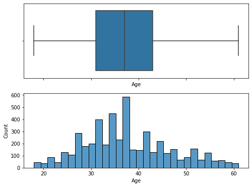

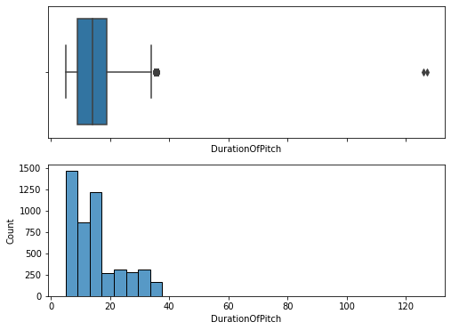

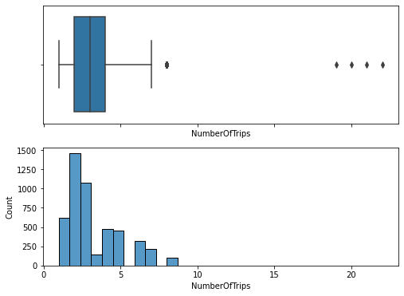

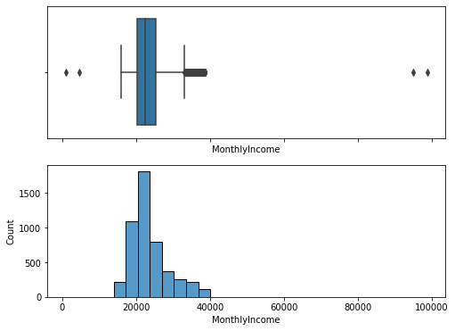

```python
for col in cols:
    box_hist_plot(df2, col)
```

We might need a log distribution for MonthlyIncome. Lets look at the outliers of MonthlyIncome, NumberofTrips and DurationOfPitch.

```python
df2.loc[df['MonthlyIncome']>80000,:]
```

|  | ProdTaken | Age | TypeofContact | CityTier | DurationOfPitch | Occupation | Gender | NumberOfPersonVisiting | NumberOfFollowups | ProductPitched | PreferredPropertyStar | MaritalStatus | NumberOfTrips | Passport | PitchSatisfactionScore | OwnCar | NumberOfChildrenVisiting | Designation | MonthlyIncome |
| --- | --- | --- | --- | --- | --- | --- | --- | --- | --- | --- | --- | --- | --- | --- | --- | --- | --- | --- | --- |
| 38 | 0 | 36.0 | Self Enquiry | 1 | 11.0 | Salaried | Female | 2 | 4.0 | Basic | 3.58 | Divorced | 1.0 | 1 | 2 | 1 | 0.0 | Executive | 95000.0 |
| 2482 | 0 | 37.0 | Self Enquiry | 1 | 12.0 | Salaried | Female | 3 | 5.0 | Basic | 5.00 | Divorced | 2.0 | 1 | 2 | 1 | 1.0 | Executive | 98678.0 |

```python
df2.loc[df['MonthlyIncome']<10000,:]
```

|  | ProdTaken | Age | TypeofContact | CityTier | DurationOfPitch | Occupation | Gender | NumberOfPersonVisiting | NumberOfFollowups | ProductPitched | PreferredPropertyStar | MaritalStatus | NumberOfTrips | Passport | PitchSatisfactionScore | OwnCar | NumberOfChildrenVisiting | Designation | MonthlyIncome |
| --- | --- | --- | --- | --- | --- | --- | --- | --- | --- | --- | --- | --- | --- | --- | --- | --- | --- | --- | --- |
| 142 | 0 | 38.0 | Self Enquiry | 1 | 9.0 | Large Business | Female | 2 | 3.0 | Deluxe | 3.0 | Single | 4.0 | 1 | 5 | 0 | 0.0 | Manager | 1000.0 |
| 2586 | 0 | 39.0 | Self Enquiry | 1 | 10.0 | Large Business | Female | 3 | 4.0 | Deluxe | 3.0 | Single | 5.0 | 1 | 5 | 0 | 1.0 | Manager | 4678.0 |

Two salaried executives' monthly incomes are stated to be \$95000 and \\$98678, which are very high. This arouses suspicion on the accuracy of the data, and since they are only two, these samples would skew the model. In the real world, this warrants more research, but for the purposes of this project, these rows will be deleted.

Row 142, a large business Manager has a monthly income of \$1000, which is very low. This will also be deleted.

```python
df2.drop(labels=[38,2482,142], axis=0, inplace=True)
df2.loc[df['MonthlyIncome']>80000,:]
```

|  | ProdTaken | Age | TypeofContact | CityTier | DurationOfPitch | Occupation | Gender | NumberOfPersonVisiting | NumberOfFollowups | ProductPitched | PreferredPropertyStar | MaritalStatus | NumberOfTrips | Passport | PitchSatisfactionScore | OwnCar | NumberOfChildrenVisiting | Designation | MonthlyIncome |
| --- | --- | --- | --- | --- | --- | --- | --- | --- | --- | --- | --- | --- | --- | --- | --- | --- | --- | --- | --- |

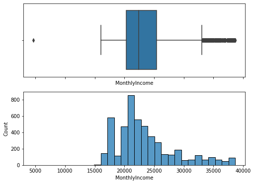

```python
# plotting MonthlyIncome again
box_hist_plot(df2, 'MonthlyIncome') # seems we dont need a log distribution anymore
```

```python
df2.loc[df['DurationOfPitch']>100,:]
```

|  | ProdTaken | Age | TypeofContact | CityTier | DurationOfPitch | Occupation | Gender | NumberOfPersonVisiting | NumberOfFollowups | ProductPitched | PreferredPropertyStar | MaritalStatus | NumberOfTrips | Passport | PitchSatisfactionScore | OwnCar | NumberOfChildrenVisiting | Designation | MonthlyIncome |
| --- | --- | --- | --- | --- | --- | --- | --- | --- | --- | --- | --- | --- | --- | --- | --- | --- | --- | --- | --- |
| 1434 | 0 | 37.62 | Company Invited | 3 | 126.0 | Salaried | Male | 2 | 3.0 | Basic | 3.0 | Married | 3.0 | 0 | 1 | 1 | 1.0 | Executive | 18482.0 |
| 3878 | 0 | 53.00 | Company Invited | 3 | 127.0 | Salaried | Male | 3 | 4.0 | Basic | 3.0 | Married | 4.0 | 0 | 1 | 1 | 2.0 | Executive | 22160.0 |

```python
df2.loc[df['NumberOfTrips']>20,:]
```

|  | ProdTaken | Age | TypeofContact | CityTier | DurationOfPitch | Occupation | Gender | NumberOfPersonVisiting | NumberOfFollowups | ProductPitched | PreferredPropertyStar | MaritalStatus | NumberOfTrips | Passport | PitchSatisfactionScore | OwnCar | NumberOfChildrenVisiting | Designation | MonthlyIncome |
| --- | --- | --- | --- | --- | --- | --- | --- | --- | --- | --- | --- | --- | --- | --- | --- | --- | --- | --- | --- |
| 816 | 0 | 39.0 | Company Invited | 1 | 15.0 | Salaried | Male | 3 | 3.0 | Deluxe | 4.0 | Single | 21.0 | 0 | 2 | 1 | 0.0 | Manager | 21782.0 |
| 3260 | 0 | 40.0 | Company Invited | 1 | 16.0 | Salaried | Male | 4 | 4.0 | Deluxe | 4.0 | Single | 22.0 | 0 | 2 | 1 | 1.0 | Manager | 25460.0 |

All of the above rows, though much above the average, look alright. So we move on...

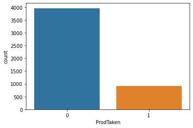

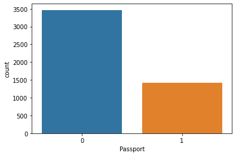

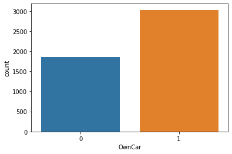

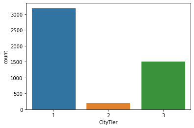

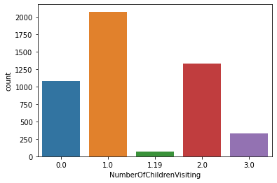

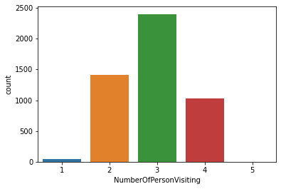

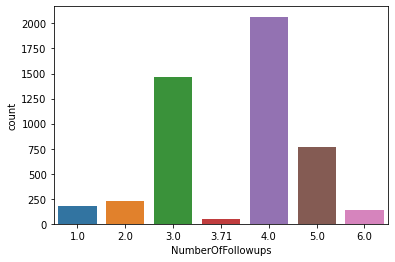

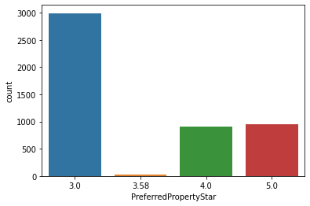

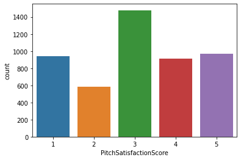

```python
for col in list1:
    sns.countplot(data=df2, x=col); plt.show()
```

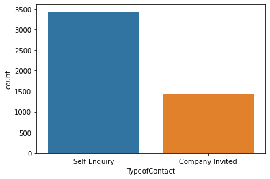

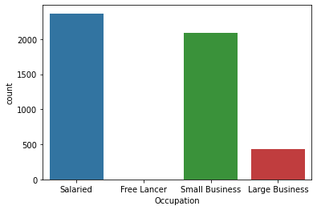

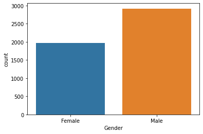

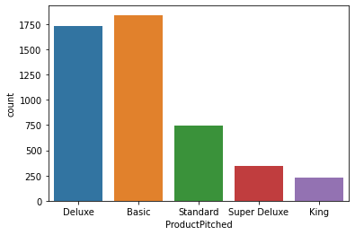

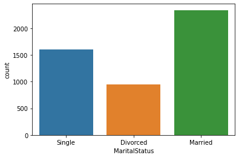

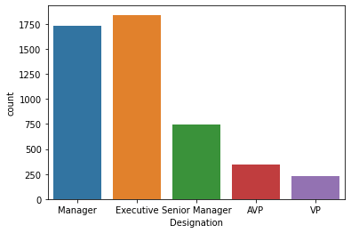

```python
cond1 = (df2.dtypes == 'object')
for col in df2.columns[cond1.values]:
    sns.countplot(data=df2, x=col); plt.show()
```

Seems like Freelancer in Occupation might have a very low number. Let's check...

```python
df2.loc[df2['Occupation'] == 'Free Lancer',:]
```

|  | ProdTaken | Age | TypeofContact | CityTier | DurationOfPitch | Occupation | Gender | NumberOfPersonVisiting | NumberOfFollowups | ProductPitched | PreferredPropertyStar | MaritalStatus | NumberOfTrips | Passport | PitchSatisfactionScore | OwnCar | NumberOfChildrenVisiting | Designation | MonthlyIncome |
| --- | --- | --- | --- | --- | --- | --- | --- | --- | --- | --- | --- | --- | --- | --- | --- | --- | --- | --- | --- |
| 2 | 1 | 37.0 | Self Enquiry | 1 | 8.0 | Free Lancer | Male | 3 | 4.0 | Basic | 3.0 | Single | 7.0 | 1 | 3 | 0 | 0.0 | Executive | 17090.0 |
| 2446 | 1 | 38.0 | Self Enquiry | 1 | 9.0 | Free Lancer | Male | 4 | 5.0 | Basic | 3.0 | Single | 8.0 | 1 | 3 | 0 | 1.0 | Executive | 20768.0 |

Summary- Most customers:

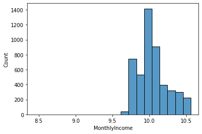

```python
# Log distribution
sns.histplot(np.log(df2.MonthlyIncome), bins=20); plt.show()
```

## Bivariate Analysis

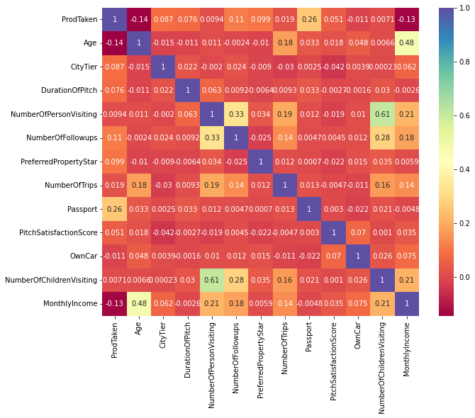

```python
plt.figure(figsize=(10,8))
sns.heatmap(df2.corr(), annot=True, cmap = 'Spectral');
```

All columns seemingly do not have a relationship with ProdTaken, except for Passport, which has a weak positive relationship. This makes sense because the ability to go on a trip depends on whether you have a passport or not.

Other relationships:

- Age has a positive relationship with monthly income
- NumberOfChildrenVisiting has a high correlation with NumberOfPersonVisiting, which might be trivial if NumberOfChildrenVisiting > 0
- NumberOfPersonVisiting has a weak correlation with NumberOfFollowups

Let's look at major relationships between ProdTaken and various independent variables.

```python
# taken help from Personal Loan Campaign solution sheet
def stacked_barplot(data, predictor, target):
    """
    Print the category counts and plot a stacked bar chart

    data: dataframe
    predictor: independent variable
    target: target variable
    """
    count  = data[predictor].nunique()
    sorter = data[target].value_counts().index[-1]
    tab1   = pd.crosstab(data[predictor], data[target], margins=True).sort_values(by=sorter, ascending=False)

    print(tab1)

    tab = pd.crosstab(data[predictor], data[target], normalize="index").sort_values(by=sorter, ascending=False)
    tab.plot(kind="bar", stacked=True, figsize=(count + 2, 6))
    plt.legend(loc="lower left", frameon=False)
    plt.legend(loc="upper left", bbox_to_anchor=(1, 1))
    plt.show()
```

```
ProdTaken     0    1   All
Passport
All        3965  920  4885
1           925  494  1419
0          3040  426  3466
```

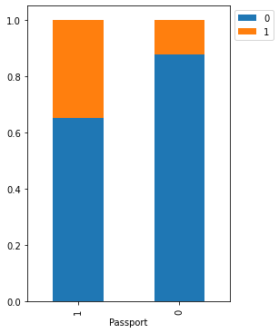

```
ProdTaken     0    1   All
OwnCar
All        3965  920  4885
1          2470  560  3030
0          1495  360  1855
```

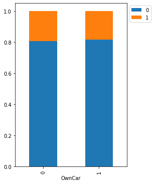

```
ProdTaken     0    1   All
CityTier
All        3965  920  4885
1          2667  520  3187
3          1146  354  1500
2           152   46   198
```

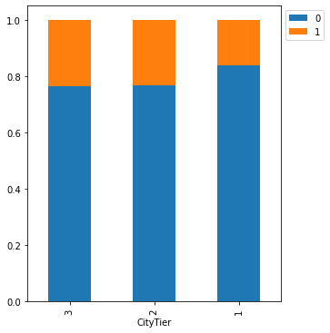

```
ProdTaken                    0    1   All
NumberOfChildrenVisiting
All                       3965  920  4885
1.0                       1687  392  2079
2.0                       1082  253  1335
0.0                        878  202  1080
3.0                        259   66   325
1.19                        59    7    66
```

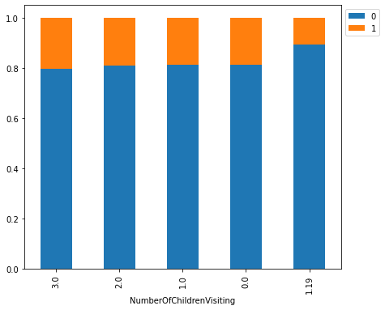

```
ProdTaken                  0    1   All
NumberOfPersonVisiting
All                     3965  920  4885
3                       1941  460  2401
2                       1149  267  1416
4                        833  193  1026
1                         39    0    39
5                          3    0     3
```

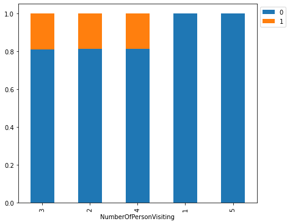

```
ProdTaken             0    1   All
NumberOfFollowups
All                3965  920  4885
4.0                1688  379  2067
3.0                1221  244  1465
5.0                 576  191   767
6.0                  82   54   136
2.0                 205   24   229
1.0                 156   20   176
3.71                 37    8    45
```

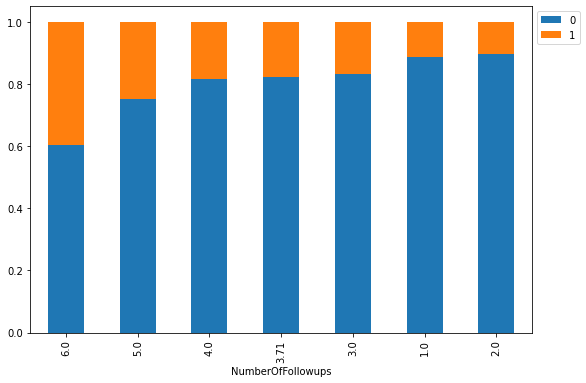

```
ProdTaken                 0    1   All
PreferredPropertyStar
All                    3965  920  4885
3.0                    2510  482  2992
5.0                     705  250   955
4.0                     731  182   913
3.58                     19    6    25
```

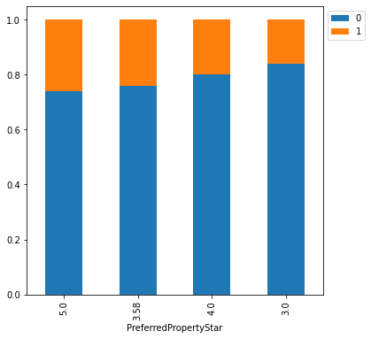

```
ProdTaken                  0    1   All
PitchSatisfactionScore
All                     3965  920  4885
3                       1162  316  1478
5                        759  210   969
4                        750  162   912
1                        798  144   942
2                        496   88   584
```

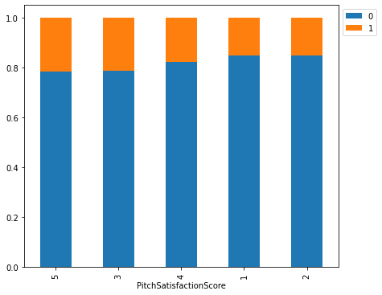

```python
for col in list1:
    if col not in ['ProdTaken']:
        stacked_barplot(df2, col,'ProdTaken')
```